# La evolución del transporte (2013-2019). Armoa - Ferenese

```r
library(tidyverse)
library (forcats)
library(dplyr)
```

La base de datos Operaciones de viaje por Periodo - Modo - Jurisdicción - Grupo Tarifario - Empresa - Línea - Tipo de Pasaje - Cantidad contiene información sobre viajes en trenes, subte, pre metro y colectivos entre 2013 y 2019. Esta base de datos se encuentra disponible en el portal [Datos Argentina](https://datos.gob.ar/it/dataset/transporte-sube-operaciones-viaje-por-mes-region-metropolitana-buenos-aires/archivo/transporte_faaf3cfa-9ce5-4f7a-8391-389ad9c2a83d).

# **El transporte: Análisis y funcionamiento a lo largo de los años**

**Pregunta:** ¿Cómo evolucionó el uso del colectivo respecto de otros medios de transporte a lo largo de los años? ¿Es igual para cualquier tipo de pasaje?

### Introducción

Nos encontramos en posesión de una base de datos oscilante entre los años 2013 y 2019, con el objetivo de constatar información sobre los viajes en distintos transportes públicos del pais. La misma nos brinda razón sobre el Periodo - Modo - Jurisdicción - Grupo Tarifario - Empresa - Línea - Tipo de Pasaje - Cantidad. Por ello, el fin de este informe es proyectar la evolución del colectivo respecto a otros medios de transporte y comparar la diferencia entre los diversos pasajes. Con esto claro, utilizaremos el periodo, el modo, la suma de las cantidades y el tipo de pasaje para obsevar si el medio predominante en dicho tramo fue variando y de qué modo.

### Enfoque

Llegados a esta instancia, realizaremos dos gráficos para representar los datos nombrados anteriormente y entender la estadística que presenta la operación del transporte a lo largo de los años.

Priméramente, realizaremos un diagrama de columnas que nos enseñará el aumento del uso de los distintos transportes en este periodo seleccionado; Dicho modo de visualización fue seleccionado por su simpleza y claridad a la hora de mostrarnos estos elementos.

Nuestro segundo gráfico será un diagrama de barras que nos muestre la cantidad de operaciones realizadas en colectivo y con qué tipo de pasaje se llevó a cabo la operación; Es utlizado este diagrama debido a las múltiples variables que presenta el objeto, buscando su lectura cómoda. Es por ello que también se optó por la inclinación a 45º de las variables en el eje X , caso contrario, su lectura sería imposible.

### Evolución del transporte a lo largo de los años

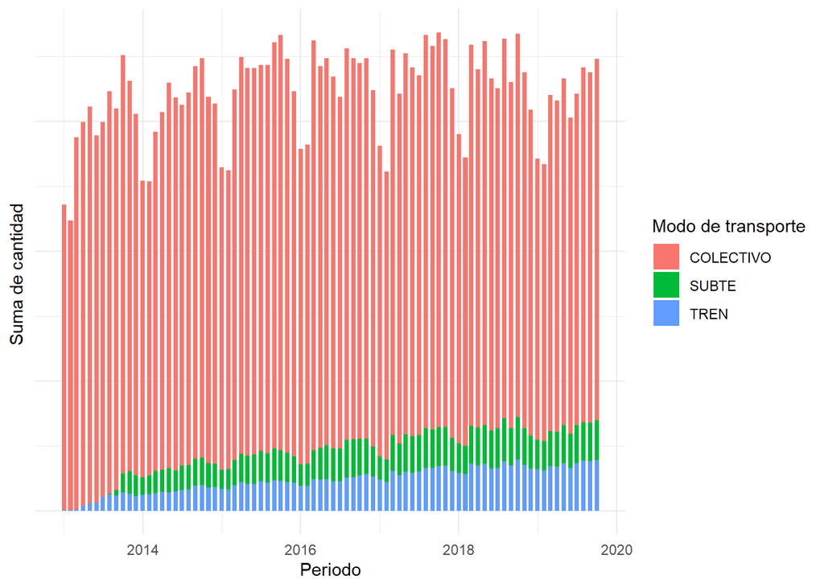

```r
sube %>%
  ggplot(aes(x = periodo, y = suma_de_cantidad, fill = modo)) +
  geom_col(width = 20) +
  labs(x = "Periodo", y = "Suma de cantidad ", fill = "Modo de transporte") +
  theme_minimal()+
  theme(axis.text.y = element_blank())
```

### Operaciones en colectivo con distintos pasajes

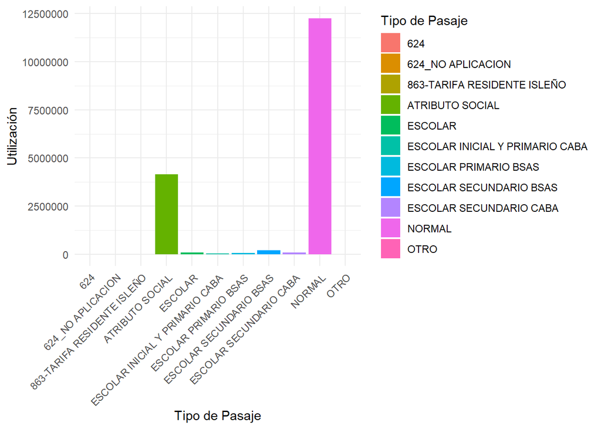

```r
sube %>%
  ggplot(aes(x = tipo_pasaje, y = suma_de_cantidad, fill = tipo_pasaje)) +
  geom_bar(stat = "identity", position = "dodge") +
  labs(x = "Tipo de Pasaje", y = "Utilización", fill = "Tipo de Pasaje") +
  theme_minimal() +
  theme(axis.text.x = element_text(angle = 45, hjust = 1))
```

### Discusión

En relación a los gráficos, debemos admitir que nos esperabamos los resultados obtenidos. La utilización del colectivo como transporte público masivo es lógica ya que se cuentan con infinitas líneas y empresas que nos llevan a todos los rincones del país. Así mismo, se puede observar como en los últimos años creció la utilización del subte y tren, que son medios destacados por los estudiantes y trabajadores.

En relación al segundo gráfico, también es de esperarse que el pico más alto se lo lleve la columna del pasaje normal de colectivo, siendo este el más utilizado por las personas que viajan en el mismo, ya que acceder a un tipo de beneficio no es sencillo y a la vez es ciertamente selectivo.

# **Estudio enfocado en la venta de pasajes de colectivos**

**Pregunta:** ¿Cómo varían los tipos de boletos vendidos por diferentes empresas de colectivo? ¿Qué ocurre si nos fijamos en la venta por jurisdicción?

### Introducción:

En el contexto de nuestro proyecto de analisis de datos, vamos a incursionarnos en la tarea de explorar y visualizar la distribucion de los tipos de boletos venididos por diversas empresas de colectivos en distintas jurisdicciones. La comprensión de cómo estos boletos se distribuyen a lo largo de diferentes regiones es fundamental para la toma de decisiones estratégicas en el sector del transporte. A través de este proyecto examinaremos las tendencias y patrones en la venta de boletos valiosos y descubrimientos claves que pueden ayudar a la empresa de colectivo a optimizar sus servicios y satisfacer las necesidades de sus clientes de manera más eficiente.

### Enfoque:

Para verificar los datos solicitados en las preguntas anteriores, realizaremos dos gráficos con el fin de visualizar de la mejor manera cómo varían los tipos de boletos vendidos por las diferentes empresas y en las distintas jurisdicciones a lo largo de los años.

En el primer caso haremos pequeños gráficos destinados a cada uno de los grupos tarifarios, con el objetivo de visualizar cuál es el tipo de boleto más vendido en las diferentes empresas de transporte a lo largo de los años según cada grupo. Se optó por este tipo de geometría porque facilita la visualización de los datos requeridos y nos brinda detalle de diversos factores importantes.

Para el segundo caso utilizaremos un grafico simple, para lograr una mayor claridad en la visualización de todos los datos relacionados con el tipo de pasaje más vendido en cada jurisdicción a lo largo de los años, logrando un gráfico simple y de fácil lectura.

### Distribución de Tipos de Boletos por Empresa

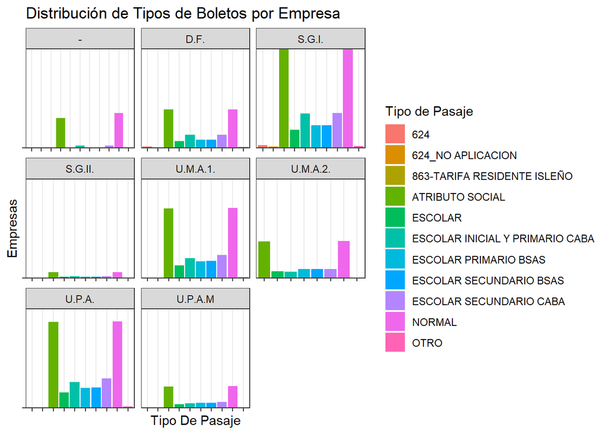

```r
sube%>%
  ggplot(aes(x = tipo_pasaje, y = empresa)) +
    geom_col(aes(fill = tipo_pasaje)) +
    labs(x = "Tipo De Pasaje", y = "Empresas",
         title = "Distribución de Tipos de Boletos por Empresa",
         fill = "Tipo de Pasaje") +
    theme_bw() +
    theme(axis.text.x = element_blank()) +
    theme(axis.text.y = element_blank()) +
    facet_wrap(~ grupo_tarifario, scales = "free_x")
```

### Tipo de Boleto segun la jurisdiccion

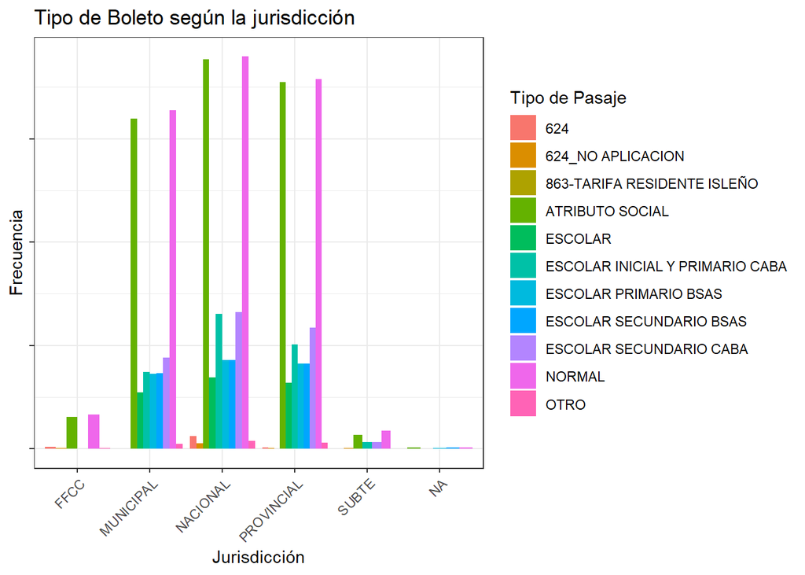

```r
sube %>%
  ggplot(aes(x = jurisdiccion)) +
  geom_bar(aes(fill = tipo_pasaje), position = "dodge") +
  labs(y = "Frecuencia", x = "Jurisdicción",
       title = "Tipo de Boleto según la jurisdicción",
       fill = "Tipo de Pasaje") +
  theme_bw() +
  theme(axis.text.x = element_text(angle = 45, hjust = 1)) +
  theme(axis.text.y = element_blank())
```

### Discusión:

Consideramos que los datos obtenidos son muy claros y lógicos, dado que la gran mayoría de personas que utiliza los diversos medios de transporte y tipos de boletos en estos casos son aquellas que viajan para dirigirse a sus lugares de trabajo, universidades, así como personas mayores o con diversas discapacidades.

En el segundo gráfico, también es evidente que a nivel nacional, provincial y municipal hay un claro predominio sobre el resto, lo cual tiene sentido debido a que es donde reside la mayor concentración de personas, las cuales diariamente exprimen la eficacia del transporte para llegar a sus trabajos o instituciones de estudio.